[figure not shown]

### Ensimag 2A

# Optimisation Numérique

## TP3: Proximal Algorithms (2x1.5h)

## GAMANGA Jérémy (MMIS), LI Maxime(IF)

# Structure of an optimization program

An optimization program can be practically divided into three parts:

- the *run* environment, in which you test, run your program, and display results.
- the *problem* part, which contains the function oracles, problem constraints, etc.
- the *algorithmic* part, where the algorithms are coded.

The main interest of such division is that these parts are interchangeable, meaning that, for instance, the algorithms of the third part can be used of a variety of problems. That is why such a decomposition is widely used.

In the present lab, you will use this division:

- `TP3_Proximal_algorithms.ipynb` will be the *run* environment
- `logistic_regression.ipynb` will be the considered *logistic regression problem* for this lab
- `algoProx.ipynb` will contain the proximal *algorithms* studied in this lab

The following script will allow you to import *notebooks* as if you imported *python files* and will have to be executed at each time you launch Jupyter notebooks.

```python
import start
from importlib import reload
```

# Composite minimization for machine learning.

In this lab, we will investigate optimization algorithms over composite functions composed of a smooth and a non-smooth part using the proximal gradient algorithm over a practical problem of machine learning: binary classification using logistic regression.</br>

> Read the file `logistic_regression_2.ipynb` contains the problem explanation and simulators.

> Implement the proximal operation linked to $\ell_1$ norm in the regularization.

> Implement the proximal gradient algorithm in the file `algoProx.ipynb` and test you algorithm below.

```python
import algoProx             # load our algoProx module (from notebook)
reload(algoProx)            # reload the module if changed (and saved)
from algoProx import *      # import all methods of the module into the current environment

import numpy as np
import logistic_regression_2 as pb
reload(pb)

#### Parameter we give at our algorithm (see algoGradient.ipynb)
PREC    = 1e-5                     # Sought precision
ITE_MAX = 1000                      # Max number of iterations
x0      = np.zeros(pb.n)              # Initial point
step    = 1.0/pb.L

##### gradient algorithm
x,x_tab = proximal_gradient_algorithm(pb.F , pb.f_grad , pb.g_prox , x0 , step , PREC, ITE_MAX , True)
```

```
importing notebook from algoProx.ipynb
importing notebook from logistic_regression_2.ipynb
importing notebook from logistic_regression_2.ipynb
------------------------------------
 Proximal gradient algorithm
------------------------------------
START    -- stepsize = 0.030334772813507393
FINISHED -- 999 iterations / 1.289900s -- final value: 0.438712
```

> Investigate the decrease of the algorithm.

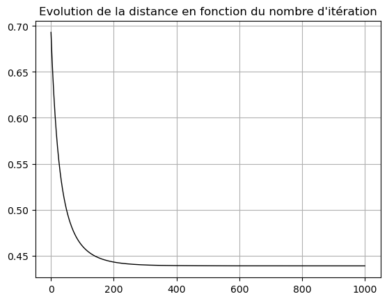

```python
import matplotlib.pyplot as plt
%matplotlib inline

F = []
for i in range(x_tab.shape[0]):
    F.append( pb.F(x_tab[i]))
plt.figure()
plt.title("Evolution de la distance en fonction du nombre d'itération")
plt.plot( F, color="black", linewidth=1.0, linestyle="-")
plt.grid(True)
plt.show()
```

[figure not shown]

```python
import matplotlib.pyplot as plt
%matplotlib inline

F = F - F[-1]
plt.figure()
plt.plot( F, color="black", linewidth=1.0, linestyle="-")
plt.yscale("log")
plt.title("Evolution de la distance en fonction du nombre d'itération")
plt.xlabel("Distance entre elements successifs")
plt.ylabel("Nb Itération")
plt.show()
```

En échelle logarithmique, on constate que la convergence est linéaire (sauf à la fin des itérations où on a une vitesse plus rapide que du linéaire). Ce qui est attendu car l'algorithme de gradient proximal à une vitesse de convergence géométrique quand f est fortement convexe.

> Plot, with the following command, the support of the vector $x_k$ (i.e. one point for every non-null coordinate of $x_k$) versus the iterations.

> What do yo notice? Was it expected?

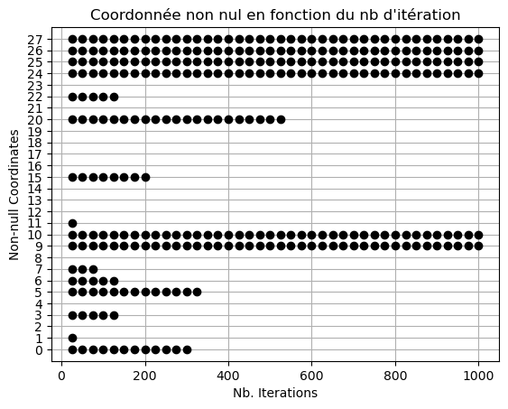

```python
plt.figure()

for i in np.arange(0,x_tab.shape[0],int(x_tab.shape[0]/40)):
    for j in range(pb.n):
        if np.abs(x_tab[i,j])>1e-14:
            plt.plot( i , j  , 'ko')

plt.grid(True)
plt.title("Coordonnée non nul en fonction du nb d'itération")
plt.ylabel('Non-null Coordinates')
plt.xlabel('Nb. Iterations')
plt.ylim(-1,pb.d+1)
plt.yticks(np.arange(0,pb.d+1))
plt.show()
```

On constate que la normalisation $l_1$ joue bien son rôle de sélection de feature. Au fil des itérations certaines coordonnées sont ramenées à 0. On remarque aussi que les coordonnées ramenées à 0, le sont relativement rapidement. En effet, l'essentielle des coordonnées misent à 0 le sont avant la 400-ième itérations sur les 1000 itérations effectuées.

# Regularization path.

We saw above that the algorithm *selected* some coordinates as the other get to zero. Considering our machine learning task (see `logistic_regression_2.ipynb`), this translates into the algorithm selecting a subset of the features that will be used for the prediction step.

> Change the parameter $\lambda_1$ of the problem (`pb.lam1`) in the code above and investigate how it influences the number of selected features.

In order to quantify the influence of this feature selection, let us consider the *regularization path* that is the support of the final points obtained by our minimization method versus the value of $\lambda_1$.

> For $\lambda_1 = 2^{-12},2^{-11}, .. , 2^{1}$, run the proximal gradient algorithm on the obtained problem and store the support of the final point, the prediction performance on the *training set* (`pb.prediction_train`) and on the *testing set* (`pb.prediction_test`).

```python
import matplotlib.pyplot as plt
%matplotlib inline

import algoProx             # load our algoProx module (from notebook)
reload(algoProx)            # reload the module if changed (and saved)
from algoProx import *      # import all methods of the module into the current environment

import numpy as np
import logistic_regression_2 as pb
reload(pb)

#### Parameter we give at our algorithm (see algoGradient.ipynb)
PREC    = 1e-5                     # Sought precision
ITE_MAX = 500                      # Max number of iterations
x0      = np.zeros(pb.n)              # Initial point
step    = 1.0/pb.L

reg_l1_tab = np.power( 2.0, np.array(range(-12,2)) )
pb.lam2 = 1e-1


### TODO

training_accuracies = []
testing_accuracies = []
support = np.empty((0,pb.n), float)

#pb.lam1 = reg_l1_tab[0]
#x1,x_tab = proximal_gradient_algorithm(pb.F , pb.f_grad , pb.g_prox , x0 , step , PREC, ITE_MAX , False)
#support = x1
#training_accuracies.append(pb.prediction_train(x,False)[1])
#testing_accuracies.append(pb.prediction_test(x,False)[1])



for lam1 in reg_l1_tab:
    pb.lam1 = lam1
    x,x_tab = proximal_gradient_algorithm(pb.F , pb.f_grad , pb.g_prox , x0 , step , PREC, ITE_MAX , False)
    support = np.vstack((support,x))
    training_accuracies.append(pb.prediction_train(x,False)[1])
    testing_accuracies.append(pb.prediction_test(x,False)[1])
```

```
importing notebook from algoProx.ipynb
importing notebook from logistic_regression_2.ipynb
importing notebook from logistic_regression_2.ipynb
```

> Plot the *regularization path* and look at the feature signification (file `student.txt` or `logistic_regression_2.ipynb`) to see which are the most important features of the dataset.

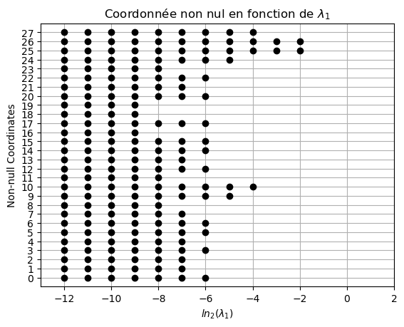

```python
# TODO
plt.figure()
for i in range(len(support)):
    for j in range(len(support[0])):
        if abs(support[i][j])>1e-14:
            plt.plot( -(12-i) , j  , 'ko')

plt.grid(True)
plt.title("Coordonnée non nul en fonction de $\lambda_1$")
plt.ylabel('Non-null Coordinates')
plt.xlabel('$ln_2(\lambda_1)$')
plt.ylim(-1,pb.d+1)
plt.xlim(-13,2)
plt.yticks(np.arange(0,pb.d+1))
plt.show()
```

> Plot the *training* and *testing* accuracies versus the value of $\lambda_1$.

On constate qu'avec un $\lambda_1$ trog grand, la normalisation $l_1$ va réduire tous les coordonnées à $0$. Alors que pour un $\lambda_1$ trog petit, aucune des coordonnées sera ramenées à $0$, il n'y a donc aucune sélection de feature. Il y a donc un $\lambda_1$ optimale qui permet de sélectionner des feature sans réduire toutes les coordonnées à $0$.

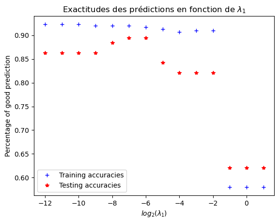

```python
lambda_log = [i for i in range(-12, 2)]
plt.plot(lambda_log, training_accuracies, 'b+', label='Training accuracies')
plt.plot(lambda_log, testing_accuracies, 'r*', label='Testing accuracies')
plt.title("Exactitudes des prédictions en fonction de $\lambda_1$")
plt.ylabel('Percentage of good prediction')
plt.xlabel('$log_2(\lambda_1)$')
plt.legend()
#print(training_accuracies[-1])
#print(testing_accuracies[-1])
```

Tout d'abord pour $ln(\lambda) = -1, 0, 1$ nous avons trois mauvais scores identiques, que ce soit en prédiction sur les données d'entraînement ou les les données de tests. Ceci s'explique par le fait que pour ces valeurs de $ln(\lambda)$ le support du vecteurs $x$, sélectionné par l'algorithme, est vide. Toutes les coordonnées du vecteurs sont nulles, ainsi $\forall (a_i,b_i)\in \mathbb{R}^d \times \mathcal{O}$ le produit scalaire $ \langle a_i , x \rangle $ donne 0 ce qui donne toujours un $p_1(a) = \frac{1}{2}$. Dans les fonctions de prédictions, nous tombons la deuxième branche conditionnelle, ce qui fait que ne prédit que $b_i$ négatif. Ainsi ces valeurs ne représentent que le nombre d'observations de label $-1$.

Pour ce qui est du reste du graphe, la précision de test est plus faible que la précision d'entraînement. Ce qui est tout à fait cohérent car le modèle, x, est une solution approchée d'une solution d'un problème d'optimisation sur les données d'entraînement. C'est donc un modèle qui donnera de meilleurs résultats sur des jeux de données qui sont très proches du jeu de données d'entraînement.

La précision d'entraînement reste au-dessus de $90\%$ et est décroissante en $ln \lambda$. Plus lambda est petit, plus la précision est bonne.

La précision de tester reste varie autour des $85\%$. Elle atteint un son maximum empirique pour $\lambda = 2^{-6}$ avec $90\%$ de bonne réponse, avant de redescendre à un taux de bonne réponse légèrement supérieur à $85\%$ pour \lambda petit$.

Sur $[\lambda = 2^{-12},\lambda = 2^{-6}]$ la précision du modèle sur le jeu de données d'entraînement augmente quand celle sur le jeu de données de test diminue. On peut penser qu'en dessous $\lambda = 2^{-6}$ il y a un sur-apprentissage du modèle qui implique une moins bonne robustesse de ce dernier quand on passe à de nouvelles données. Ce sur-apprentissage apparaît car $\lambda_1$ est trop petit, son poids dans la fonction objective devient négligeable devant la fonction de perte logistique. Or, c'est cette dernière qui quantifie la précision de notre modèle sur les données d'entrainements. Donc, notre modèle optimisé surtout sa précision sur les données d'entraînement.

Quand $\lambda_1$ augmente, son poids dans la fonction objective augmente et de ce fait on donne moins d'importance à la fonction de perte logistique. Or, c'est cette dernière qui quantifie la précision de notre modèle sur les données d'entrainements. D'où, la perte de précision quand $\lambda_1$ augmente.

> Same Question with $\lambda_2$

```python
PREC    = 1e-4                     # Sought precision
ITE_MAX = 10000                    # Max number of iterations
x0      = np.zeros(pb.n)              # Initial point
step    = 1.0/pb.L

reg_l2_tab = np.power( 2.0, np.array(range(-12,2)) )
pb.lam1 = 0.03


### TODO

training_accuracies = []
testing_accuracies = []
support = np.empty((0,pb.n), float)
L = []

for lam2 in reg_l2_tab:
    pb.lam2 = lam2
    x,x_tab = proximal_gradient_algorithm(pb.F , pb.f_grad , pb.g_prox , x0 , step , PREC, ITE_MAX , False)
    support = np.vstack((support,x))
    #print(x_tab.shape[0])
    L.append(x_tab.shape[0])
    training_accuracies.append(pb.prediction_train(x,False)[1])
    testing_accuracies.append(pb.prediction_test(x,False)[1])
```

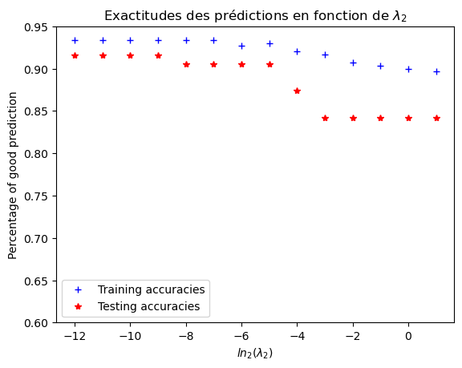

```python
# TODO
lambda_log = [i for i in range(-12,2)]
plt.plot(lambda_log, training_accuracies, 'b+', label='Training accuracies')
plt.plot(lambda_log, testing_accuracies, 'r*', label='Testing accuracies')
plt.title("Exactitudes des prédictions en fonction de $\lambda_2$")
plt.ylabel('Percentage of good prediction')
plt.xlabel('$ln_2(\lambda_2)$')
plt.ylim(0.6, 0.95)
plt.legend()
```

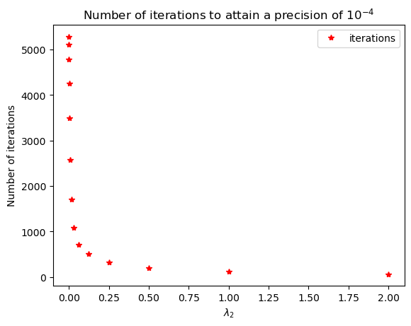

```python
plt.plot(reg_l2_tab, L, 'r*', label='iterations')
plt.ylabel('Number of iterations')
plt.title("Number of iterations to attain a precision of $10^{-4}$")
plt.xlabel('$\lambda_2$')
plt.legend()
```

```python
print("L est égale à ", pb.L, ".")
```

```
L est égale à  32.965468577853414 .
```

$||x_{k+1}-x^*||\leq \left(\dfrac{1-\kappa}{1+\kappa}\right)^k||x_{0}-x^*||$ Avec $\kappa$ = $\dfrac{\lambda_2}{L}\leq 1$ et $x^*$ la solution du problème.

D'après cette inégalité, il est cohérent que la vitesse de convergence augmente (le nombre d'itérations diminue) quand $\lambda_2$ augmente.

Comme $\kappa \geq 0 $, on a $||x_{k+1}-x^*||\leq \left(1-\kappa\right)^k||x_{0}-x^*||$

Si l'on a un critère d'arrêt du type $||x_{k+1}-x^*||\leq \epsilon $ avec $ \epsilon \gt 0$, l'algorithme s'arrête quand : $ \left(1-\kappa\right)^k||x_{0}-x^*|| \leq \epsilon$.

On passe au log dans l'inégalité, on obtient: $ k \log{\left(1-\kappa\right)} + \log{||x_{0}-x^*||} \leq \log{\epsilon}$

Soit : $ k \log{\left(1-\kappa\right)} \leq \log{\frac{\epsilon}{||x_{0}-x^*||}} = -C$, une constante positive) ($\epsilon \leq ||x_{0}-x^*||$ sinon l'algorithme s'arrête avec 0 itération. )

Comme on fait varier $\lambda_1$ dans $]0,2[$ et que $L \approx 33 $ on peut considérer que $\kappa$ est très petit devant $1$.

Donc : $$ k \leq \frac{-C}{\log{\left(1-\kappa\right)}}$$

or $\log(1-\kappa) \sim -\kappa$ quand $\kappa$ tend vers 0.

Donc $$ k \leq \frac{C}{\kappa + O(\kappa)}$$

Ainsi k est majoré par une fonction équivalente à $$\frac{C}{\kappa} = \frac{C\times L}{\lambda_2}$$

Donc il n'est pas surprenant de retrouver une décroissance en $\frac{1}{\lambda_2}$

# Un autre critère d'arrêt ?

Un autre critère d'arrêt peut se baser sur le score de prédiction de notre modèle sur les données d'entraînements et/ou de tests. Il est clair que ne prendre en compte que le score de prédiction de notre modèle sur les données d'entrainements va aboutir à un sur-apprentissage de notre modèle. Afin d'éviter cela, nous allons utiliser une méthode de cross-validation. Le modèle va être entraîné sur les données d'entraînement puis être validé par nos données de tests (qui vont donc devenir nos données de validation). A chaque "pas d'itérations", par exemple tous les 10, 20, 50, 100 ... itérations, le modèle sera évalué sur le jeu de données de validation. Une fois que la précision sur les données aura atteint un palier, l'algorithme s'arrêtera. Il faudra ensuite un troisième jeu de données afin de tester notre modèle (car il est normal qu'il soit plus performant sur les données de validations à cause de ce procédé).

Nous implémentons une nouvelle version de l'algorithme dans algoProx.ipynb : proximal_gradient_algorithm2

```python
import algoProx             # load our algoProx module (from notebook)
reload(algoProx)            # reload the module if changed (and saved)
from algoProx import *      # import all methods of the module into the current environment

import numpy as np
import logistic_regression_2 as pb
reload(pb)

PREC    = 1e-4                     # Sought precision
ITE_MAX = 10000                    # Max number of iterations
x0      = np.zeros(pb.n)              # Initial point
step    = 1.0/pb.L
PREC_VALIDATION =  1e-8             # precision on the difference between two validation error
PAS = 10                           # number of itération between two test on the validation test
print("\nNew stop condition with PAS = 10:")
x2,_ = proximal_gradient_algorithm2(pb.F , pb.f_grad , pb.g_prox , x0 , step , PAS, PREC_VALIDATION, ITE_MAX , True)
print("training score:",pb.prediction_train(x2,False)[1])
print("validation score: ", pb.prediction_test(x2,False)[1])
print("\n")

PAS = 100
print("\nNew stop condition with PAS = 100:")
x2,_ = proximal_gradient_algorithm2(pb.F , pb.f_grad , pb.g_prox , x0 , step , PAS, PREC_VALIDATION, ITE_MAX , True)
print("training score:",pb.prediction_train(x2,False)[1])
print("validation score: ", pb.prediction_test(x2,False)[1])
print("\n")

print("\nClassic stop condition:")
x,_ = proximal_gradient_algorithm(pb.F , pb.f_grad , pb.g_prox , x0 , step , PREC, ITE_MAX , True)
print("training score:",pb.prediction_train(x,False)[1])
print("test score: ", pb.prediction_test(x,False)[1])
print("\n")
```

```
importing notebook from algoProx.ipynb
importing notebook from logistic_regression_2.ipynb
importing notebook from logistic_regression_2.ipynb

New stop condition with PAS = 10:
------------------------------------
 Proximal gradient algorithm
------------------------------------
START    -- stepsize = 0.030334772813507393
FINISHED -- 10 iterations / 0.015078s -- final value: 0.613516


training score: 0.8866666666666667
validation score:  0.8315789473684211



New stop condition with PAS = 100:
------------------------------------
 Proximal gradient algorithm
------------------------------------
START    -- stepsize = 0.030334772813507393
FINISHED -- 200 iterations / 0.258075s -- final value: 0.442797


training score: 0.9066666666666666
validation score:  0.8421052631578947



Classic stop condition:
------------------------------------
 Proximal gradient algorithm
------------------------------------
START    -- stepsize = 0.030334772813507393
FINISHED -- 589 iterations / 0.769997s -- final value: 0.438741


training score: 0.9133333333333333
test score:  0.8421052631578947
```

On constate qu'on a un résultat similaire à l'algorithme avec un condition d'arrêt sur l'écart entre deux termes successifs de la suite mais uniquement quand on choisit un pas assez grand. En effet, on peut avoir un palier local pour les erreurs de prédictions avant de découvrir un autre palier avec un taux d'erreur plus bas. Le choix du PAS semble donc conditionner la qualité du modèle.  
Regardons l'évolution de ce dernier plus en détails :

```python
training_accuracies = []
testing_accuracies = []
number_iteration = []
PAS_list = range(1, 500, 2)
for pas in PAS_list:
    x,x_tab = proximal_gradient_algorithm2(pb.F , pb.f_grad , pb.g_prox , x0 , step , pas, 1e-8, ITE_MAX , False)
    training_accuracies.append(pb.prediction_train(x,False)[1])
    testing_accuracies.append(pb.prediction_test(x,False)[1])
    number_iteration.append(len(x_tab))
```

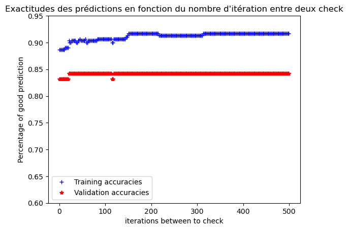

```python
plt.plot(PAS_list, training_accuracies, 'b+', label='Training accuracies')
plt.plot(PAS_list, testing_accuracies, 'r*', label='Validation accuracies')
plt.title("Exactitudes des prédictions en fonction du nombre d'itération entre deux check")
plt.ylabel('Percentage of good prediction')
plt.xlabel('iterations between to check')
plt.ylim(0.6, 0.95)
plt.legend()
```

On constate qu'on a bien un bien la précision sur les données d'entraînement qui continue à augmenter par palier et notre précision sur les données de validation qui stagne. Ainsi les paliers pour la précision sur les données d'entraînement montrent qu'on arrive à limiter le sur-apprentissage avec un bon choix de PAS. Mais ce choix va conditionner la limite qu'on impose à la précision sur les données d'entraînement.